# MIE237

2016-01-29

## Regression

## Linear models

- Model: Output = Input + Noise
- \(Y_{i} = \beta_0 + \beta_1 x_i + \varepsilon_{i},\quad x_i\in\mathbb{R}\)
- \(Y_{i} = \beta_0 + \beta_1 x_{1i} + \beta_2 x_{2i}+ \varepsilon_{i},\quad x_{ji}\in\mathbb{R}\)
- \(Y_{i} = \beta_0 + \beta_1 x_{1i} + \cdots + \beta_k x_{ki}+ \varepsilon_{i},\quad x_{ji}\in\mathbb{R}\)

In each case \({\varepsilon}_i \sim N(0,\sigma^2)\).

## Linear models in matrix form

\[\boldsymbol{Y} = \boldsymbol X\boldsymbol{\beta}+\boldsymbol{\varepsilon}\]

\[\boldsymbol{Y} = \begin{bmatrix}Y_1\\\vdots\\Y_n\end{bmatrix}\]

\[\boldsymbol{\beta} = \begin{bmatrix}\beta_0\\\beta_1\\\vdots\\\beta_k \end{bmatrix}\]

\[\boldsymbol{\varepsilon} = \begin{bmatrix} \varepsilon_1\\ \varepsilon_2\\ \vdots\\ \varepsilon_n\\ \end{bmatrix}\]

## Linear models in matrix form

\[\boldsymbol{Y} = \boldsymbol X\boldsymbol{\beta}+\boldsymbol{\varepsilon}\]

\[\boldsymbol{X} = \begin{bmatrix} 1&x_{11}&x_{21}&\cdots&x_{k1}\\ 1&x_{12}&x_{22}&\cdots&x_{k2}\\ \vdots&\vdots&\vdots&\vdots&\vdots\\ 1&x_{1n}&x_{2n}&\cdots&x_{kn}\\ \end{bmatrix}\]

## "Simple" linear regression

\[Y_i = \beta_0 + \beta_1 x_i + {\varepsilon}_i\]

\[{\varepsilon}\sim N(0,\sigma^2)\]

\(\beta_1\) is the "slope" parameter and \(\beta_1\) is the "intercept" parameter. So there are three unknown parameters that need to be estimated using data.

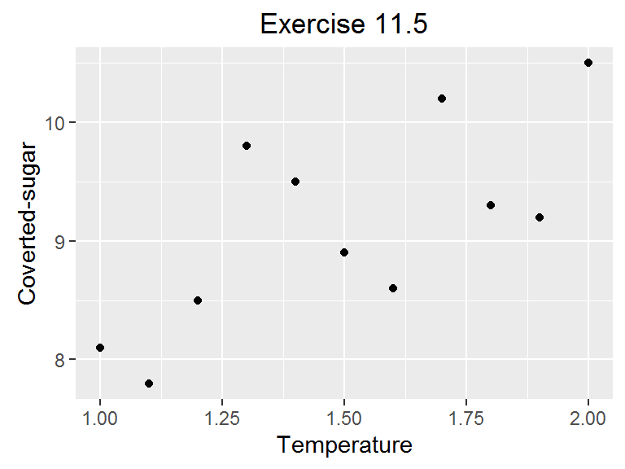

## Parameter interpretation

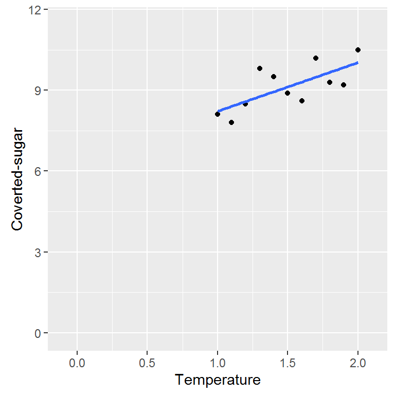

The slope is the change in \(y\) when \(x\) changes by 1 unit.

The intercept rarely matters in and of itself.

Caution: plots usually present regression data with axes rescaled to be pleasing to the eye.

## Example regression results using R (ugly version)

```
##
## Call:
## lm(formula = `Coverted-sugar` ~ Temperature, data = .)
##
## Residuals:
##     Min      1Q  Median      3Q     Max
## -0.7082 -0.4868 -0.1227  0.5109  1.0346
##
## Coefficients:
##             Estimate Std. Error t value Pr(>|t|)
## (Intercept)   6.4136     0.9246   6.936 6.79e-05 ***
## Temperature   1.8091     0.6032   2.999    0.015 *
## ---
## Signif. codes:  0 '***' 0.001 '**' 0.01 '*' 0.05 '.' 0.1 ' ' 1
##
## Residual standard error: 0.6326 on 9 degrees of freedom
## Multiple R-squared:  0.4999, Adjusted R-squared:  0.4443
## F-statistic: 8.996 on 1 and 9 DF,  p-value: 0.01497
```

## Pretty version

|  | Estimate | Std. Error | t value | Pr(>\|t\|) |
| --- | --- | --- | --- | --- |
| (Intercept) | 6.4136 | 0.9246 | 6.94 | 0.0001 |
| Temperature | 1.8091 | 0.6032 | 3.00 | 0.0150 |

## Preview of "correlation"

Recall \(\text{Cov}(X,Y) = E(X-E(X))(Y-E(Y)) = E(XY)-E(X)E(Y)\).

Measures linear relationship between \(X\) and \(Y\).

A related measure that divides by the two standard deviations:\[\rho = \frac{\text{Cov}(X,Y)}{\sqrt{{\text{Var}\left( X \right)} {\text{Var}\left( Y \right)}}}\]

"Correlation coefficient"

## Preview of correlation

\(\rho\) is a measure of the linear relationshipbetween the random variables \(X\) and \(Y\).

We'd like an analogous *empirical* measure for *sample data*:

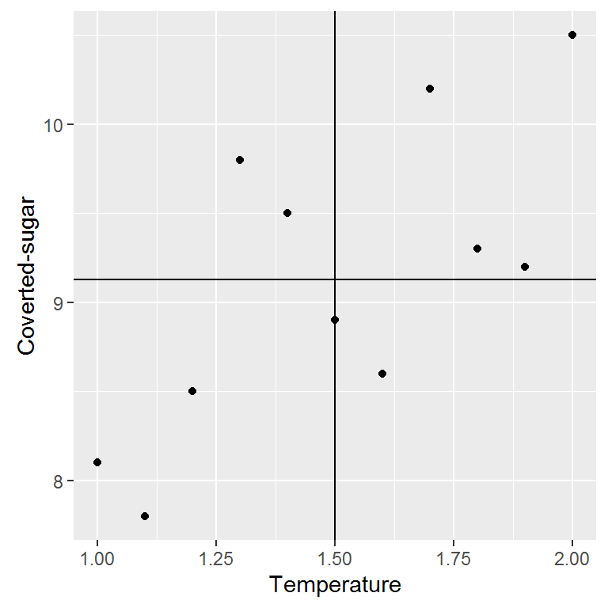

We will base it on:

\(S_{xy}=\sum_{i=1}^n \left(x_i-\overline x\right) \left(y_i - \overline y\right)\)

(more on this later…)

## "Least squares" estimation for model parameters

Model: \(Y_i = \beta_0 + \beta_1 x_i + \varepsilon_i\) (Or: \({\boldsymbol{Y}} = {\boldsymbol{X}} {\boldsymbol{\beta}} + {\boldsymbol{\varepsilon}}\))

Estimation method is to minimize (for \(\beta_0\) and \(\beta_1\)) the "squared error":\[\sum_{i=1}^n \varepsilon_i^2 = \sum_{i=1}^n \left(Y_i-\beta_0-\beta_1x_i\right)^2\]

More generally, minimize:\[{\boldsymbol{\varepsilon}}^\prime{\boldsymbol{\varepsilon}}= \left({\boldsymbol{Y}}-{\boldsymbol{X\beta}}\right)^\prime\left({\boldsymbol{Y}}-{\boldsymbol{X\beta}}\right) \]

## Results

\[\hat{\beta_1} = \frac{S_{xY}}{S_{xx}}\]

where \(S_{xx}=\sum_{i=1}^n \left(x_i-\overline x\right)^2\) (scales out the variation in the \(x\) direction)

and

\[\hat{\beta_0} = {\overline{Y}} - \hat{\beta_1} \overline x\]

More generally:\[\hat{{\boldsymbol{\beta}}} = ({\boldsymbol{X}}' {\boldsymbol{X}})^{-1}{\boldsymbol{X}}' {\boldsymbol{y}}\]where the key thing to notice is that it involves a matrix inversion.

## More on \(\hat\beta_1\)

Estimation based on the model \(Y_i = \beta_0 + \beta_1 x_i + \varepsilon_i\).

Other model assumptions: \(\varepsilon_i\) are i.i.d. \(N(0, \sigma^2)\). So the \(Y_i\) are also normal, with mean \(\beta_0 + \beta_1x_i\) and variance \(\sigma^2\).

Important to remember that \(\hat\beta_1\) is a *random variable* with a distribution, mean, and variance of its own. (\(\beta_0\) too.)